# Visualizing Shape Differences and Principal Components Analysis

Antigoni Kaliontzopoulou, Dean Adams & Michael Collyer

28 May, 2026

## **Content Description**

In this tutorial, we demonstrate some of the graphical capabilities of `geomorph` that may be used to visualize patterns of shape variation, and interpret particular shape differences between specimens. These types of plots, shape difference plots and principal components plots, are found in nearly every empirical publication using geometric morphometric shape data, and are thus of primary importance. `Geomorph` now has considerable flexibility in plot options for these visualizations, and we encourage you to explore these options and consult the help pages of the various functions.

First, let´s load some example data and plot the specimens (before and after GPA alignment):

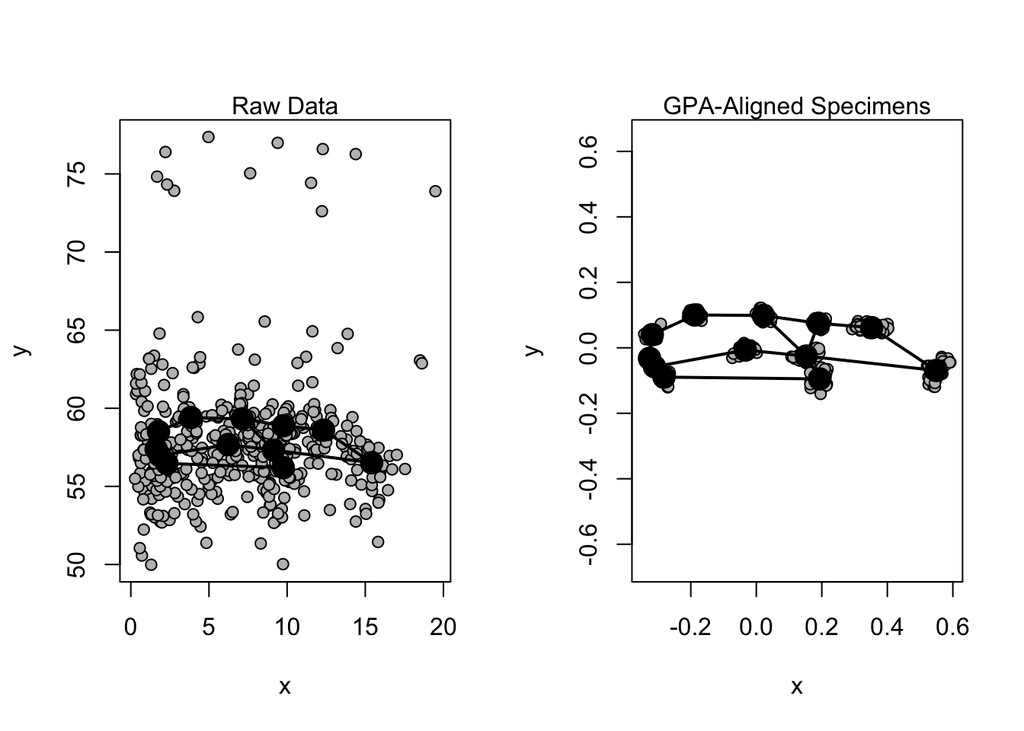

```r
library(geomorph)
data(plethodon)
Y.gpa <- gpagen(plethodon$land, print.progress = F)    # GPA-alignment

par(mfrow=c(1,2))
plotAllSpecimens(plethodon$land, links=plethodon$links)  # Raw data
mtext("Raw Data")
plotAllSpecimens(Y.gpa$coords, links=plethodon$links)    # GPA-aligned data
mtext("GPA-Aligned Specimens")
```

```r
par(mfrow=c(1,1))
```

## **1: Visualize Shape Differences Between Specimens**

Visualizing shape deformations is **ALWAYS** relative to some reference. That is, we provide graphical depictions of shape *differences* $\small{Reference\rightarrow{Target}}$. Typically, we use the overall average as a reference, and deform it into some target using the function `plotRefToTarget`. There are quite a few plotting options available: a few of them are illustrated here (but see the help files for more details!).

**Here we demonstrate several shape deformation plots as found in `geomorph`

### Deformations Specimen to Specimen

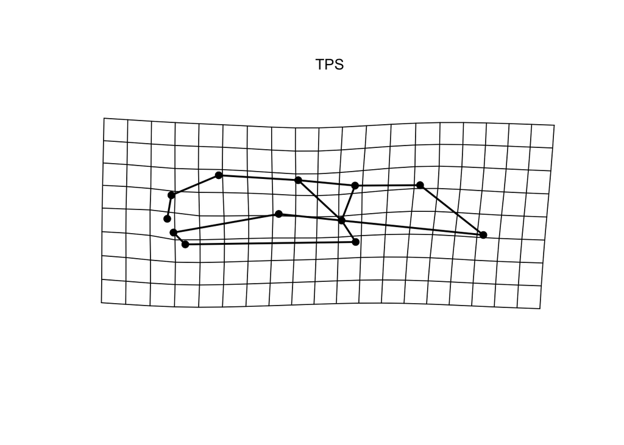

```r
ref <- mshape(Y.gpa$coords)

plotRefToTarget(ref,Y.gpa$coords[,,39], links=plethodon$links)
mtext("TPS")
```

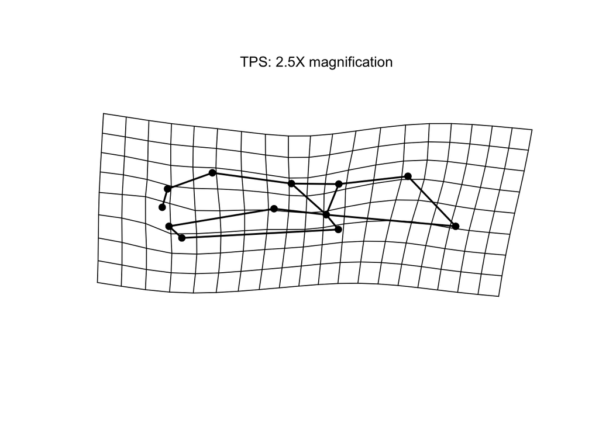

```r
plotRefToTarget(ref,Y.gpa$coords[,,39], mag=2.5, links=plethodon$links)
mtext("TPS: 2.5X magnification")
```

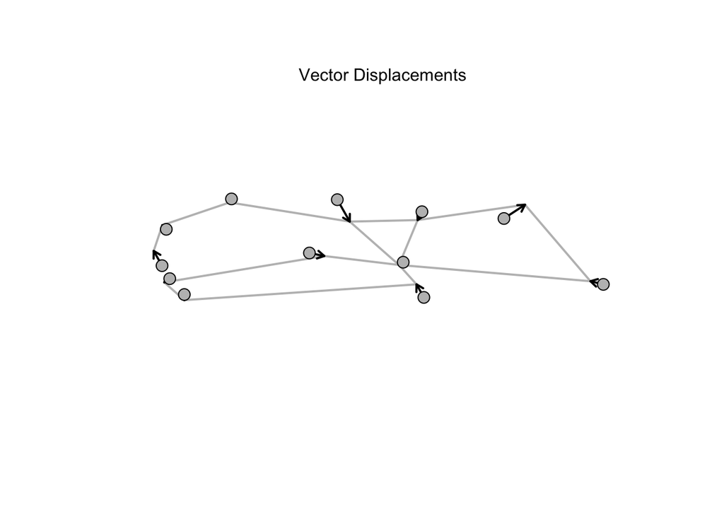

```r
par(mfrow=c(1,1))

plotRefToTarget(ref,Y.gpa$coords[,,39], links=plethodon$links, method="vector", mag=3)
mtext("Vector Displacements")
```

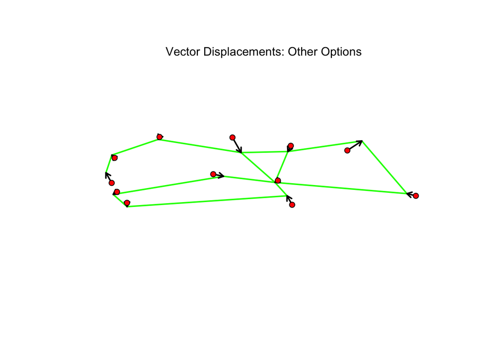

```r
plotRefToTarget(ref,Y.gpa$coords[,,39], links=plethodon$links,gridPars=gridPar(pt.bg="red", link.col="green", pt.size = 1), method="vector", mag=3)
mtext("Vector Displacements: Other Options")
```

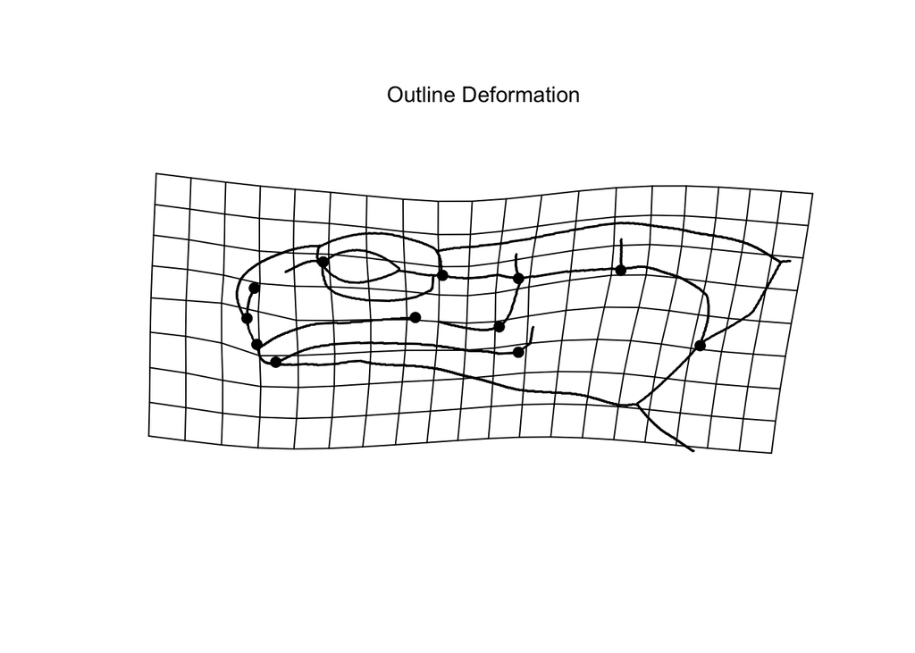

```r
plotRefToTarget(ref,Y.gpa$coords[,,39], mag=2, outline=plethodon$outline)
mtext("Outline Deformation")
```

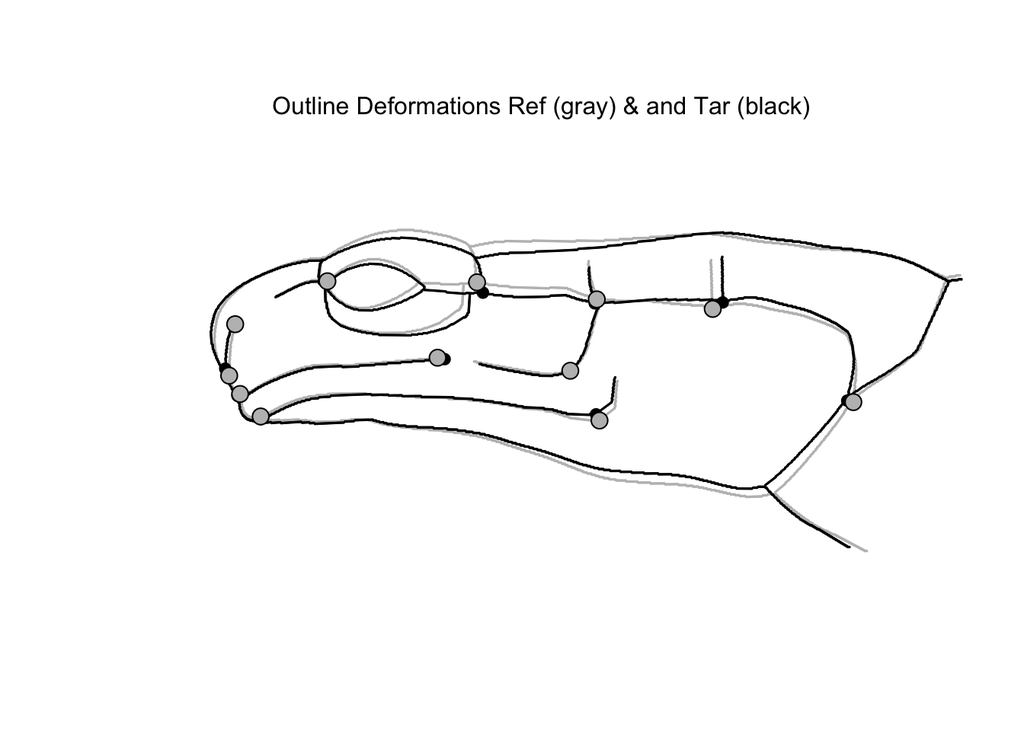

```r
plotRefToTarget(ref,Y.gpa$coords[,,39], method="points", outline=plethodon$outline)
mtext("Outline Deformations Ref (gray) & and Tar (black)")
```

## **2: Advanced Shape Plotting: Shape Prediction**

Many times, we wish to visualize shape deformations based on a particular statistical model. For instance, we may wish to visualize group differences from ANOVA, or visualize how shape changes along some axis, like a regression line or a PC-axis. All of these require *Predicting* shapes based on some mathematical model, and then visualizing shape deformations using those predicted shapes.

While the mathematics of this can become rather involved, it is straightforward. Fortunately, `geomorph` has a wonderful and general function to accomplish this task: `shape.predictor`. Here we demonstrate a few of its capabilities (**NOTE: in future lectures we will discuss the mathematics of these statistical methods. Here the visualization tools only are demonstrated):

### PCA Shape Predictions

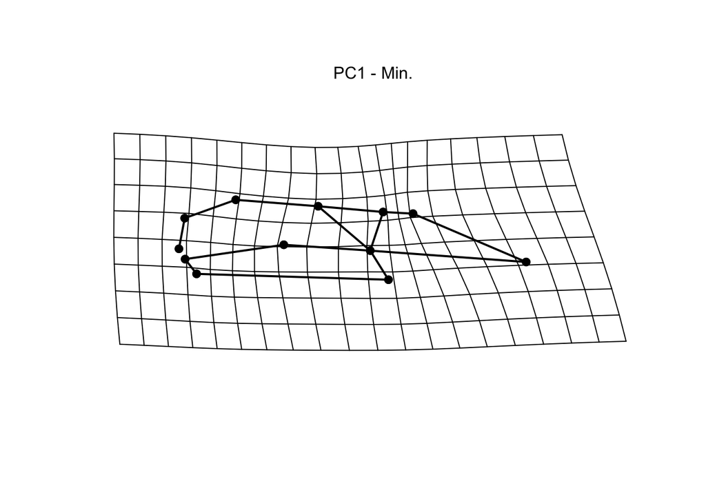

```r
M <- mshape(Y.gpa$coords)
PCA <- gm.prcomp(Y.gpa$coords)
PC <- PCA$x[,1]
preds <- shape.predictor(Y.gpa$coords, x = PC, Intercept = FALSE,
                         pred1 = min(PC), pred2 = max(PC)) # PC 1 extremes, more technically
# Note that these are actually already included in the PCA object in the list "shapes"
plotRefToTarget(M, preds$pred1, links = plethodon$links)
mtext("PC1 - Min.")
```

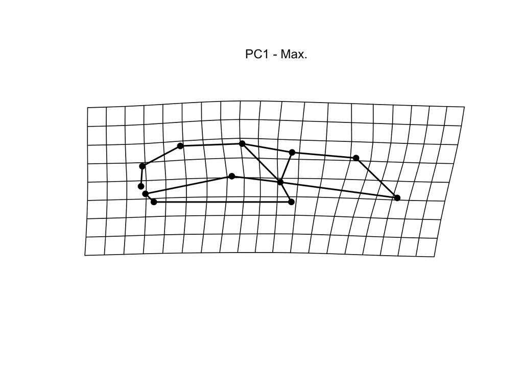

```r
plotRefToTarget(M, preds$pred2, links = plethodon$links)
mtext("PC1 - Max.")
```

### Shape Predictions Along a Regression

Many times, we fit a linear model in the form of regression (e.g., allometry). Here is how we visualize shape changes along the extremes of that regression using `shape.predictor`:

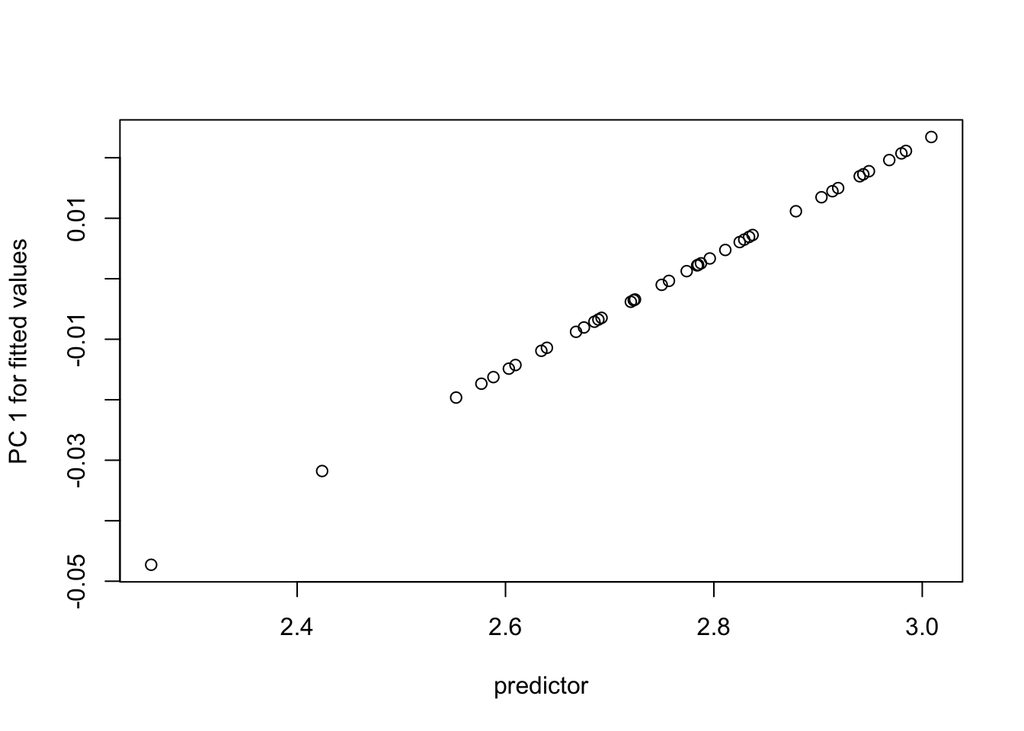

```r
gdf <- geomorph.data.frame(Y.gpa)
plethAllometry <- procD.lm(coords ~ log(Csize), data=gdf, print.progress = FALSE)
allom.plot <- plot(plethAllometry,
                   type = "regression",
                   predictor = log(gdf$Csize),
                   reg.type ="PredLine") # make sure to have a predictor
```

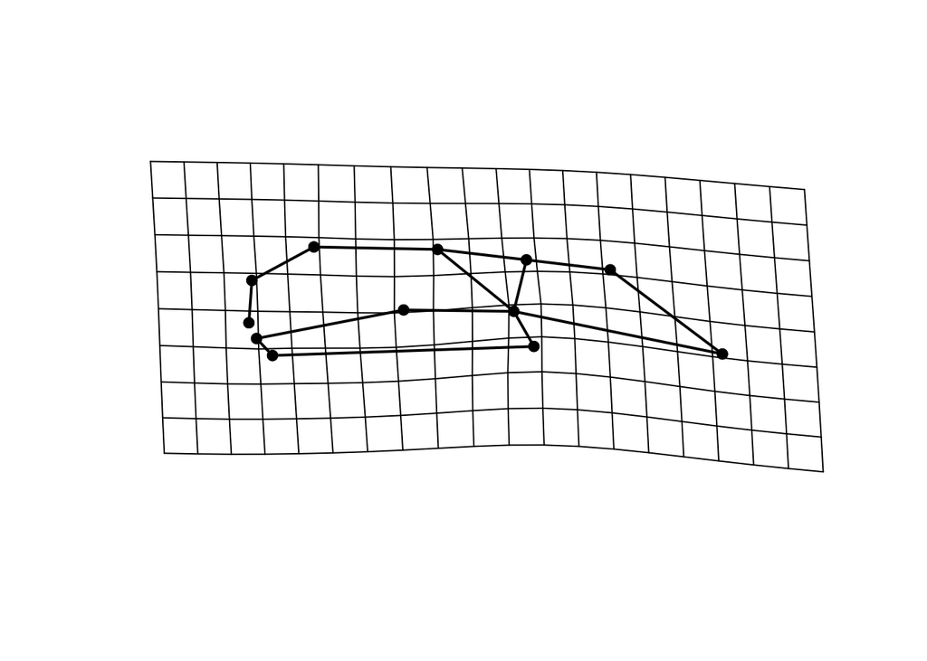

```r
preds <- shape.predictor(plethAllometry$GM$fitted, x= allom.plot$RegScore, Intercept = FALSE,
                         predmin = min(allom.plot$RegScore),
                         predmax = max(allom.plot$RegScore))
plotRefToTarget(M, preds$predmin, mag=3, links = plethodon$links)
```

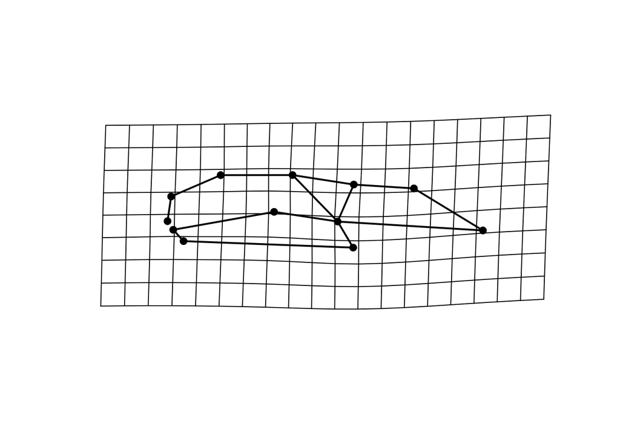

```r
plotRefToTarget(M, preds$predmax, mag=3, links = plethodon$links)
```

### Shape Predictions of Group Differences

Another very common statistical design is one of evaluating group differences in shape (i.e., ANOVA). Here we wish to visualize shape differences among groups. Below is an example:

```r
gdf <- geomorph.data.frame(Y.gpa, species = plethodon$species, site = plethodon$site)
pleth.anova <- procD.lm(coords ~ species*site, data=gdf, print.progress = FALSE)
X <- pleth.anova$X
X # includes intercept; remove for better functioning
```

```
##    (Intercept) speciesTeyah siteSymp speciesTeyah:siteSymp
## 1            1            0        1                     0
## 2            1            0        1                     0
## 3            1            0        1                     0
## 4            1            0        1                     0
## 5            1            0        1                     0
## 6            1            0        1                     0
## 7            1            0        1                     0
## 8            1            0        1                     0
## 9            1            0        1                     0
## 10           1            0        1                     0
## 11           1            1        1                     1
## 12           1            1        1                     1
## 13           1            1        1                     1
## 14           1            1        1                     1
```

[output cut: 34 more lines]

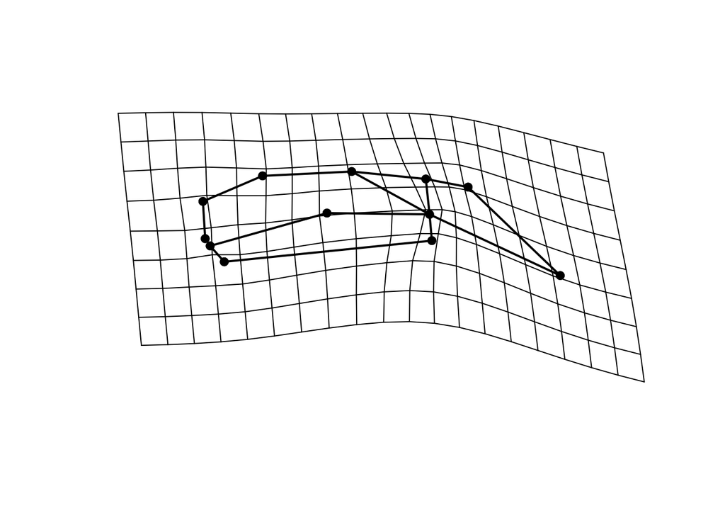

```r
X <- X[,-1]
symJord <- c(0,1,0) # design for P. Jordani in sympatry
alloJord <- c(0,0,0) # design for P. Jordani in allopatry
preds <- shape.predictor(arrayspecs(pleth.anova$fitted, 12, 2), x = X, Intercept = TRUE,
                         symJord=symJord, alloJord=alloJord)
plotRefToTarget(M, preds$symJord, links = plethodon$links, mag=2)
```

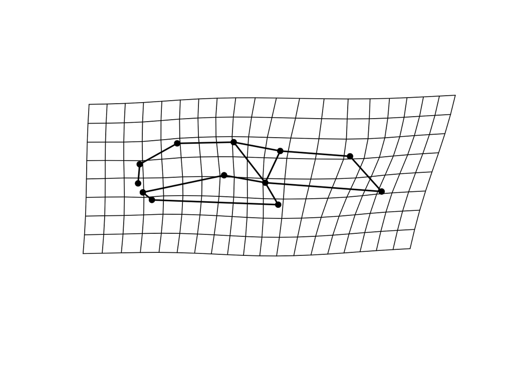

```r
plotRefToTarget(M, preds$alloJord, links = plethodon$links, mag=2)
```

## **3: PCA Plot**

In `geomorph`, the function `gm.prcomp` provides great flexibility for different types of PCAs. Here we only showcase the basic PCA capacities.

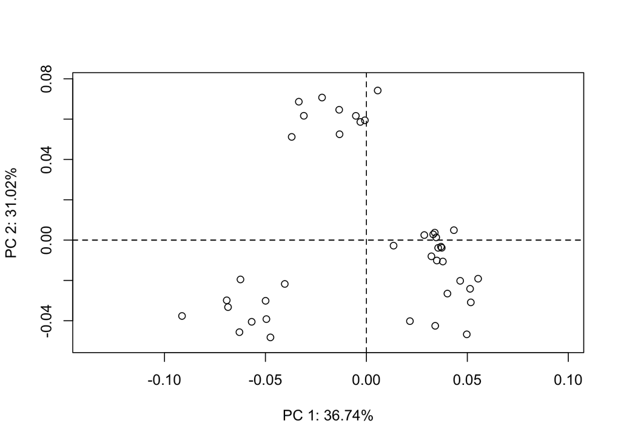

```r
pleth.raw <- gm.prcomp(Y.gpa$coords)
gps <- as.factor(paste(plethodon$species, plethodon$site))
plot(pleth.raw)
```

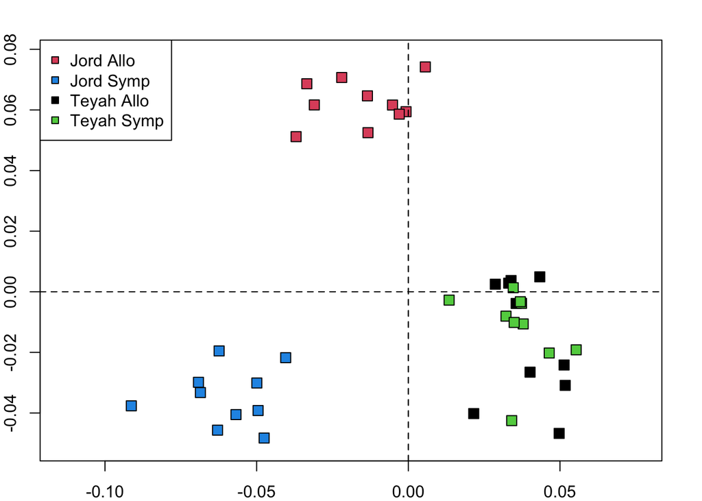

```r
par(mar=c(2, 2, 2, 2))
plot(pleth.raw, pch=22, cex = 1.5, bg = gps)
#  Add things as desired using standard R plotting
legend("topleft", pch=22, pt.bg = unique(gps), legend = levels(gps))
```

## **4: Selecting Shapes to Visualize in Real Time**

One recent enhancement of `geomorph` is the `picknplot.shape` function. With this function, one can select locations in a statistical dataspace, and `geomorph` will mathematially back-translate the statistical summary values in the plot to obtain landmark coordinates, and will then generate a thin-plate spline deformation grid of a specimen that would exist at that location in the dataspace.

This real-time visualization is especially useful for viewing regions of morphospace that are unoccupied by the sample of specimens, and for exploring other non-sampled shapes.

##### Note: because this is an interactive function, the code is repeated below but not run.

```r
# 2d
# data(plethodon)
# Y.gpa <- gpagen(plethodon$land)
# pleth.pca <- gm.prcomp(Y.gpa$coords)
# pleth.pca.plot <- plot(pleth.pca)
# picknplot.shape(pleth.pca.plot)
# May change arguments for plotRefToTarget
# picknplot.shape(plot(pleth.pca), method = "points", mag = 3, links=plethodon$links)
```

## **5: 3D warping**

`Geomorph` also has the ability to generate shape deformations of 3D objects. Again this is interactive code, so it is repeated, but not run, below:

```r
#scallops <- readland.tps("Data/scallops for viz.tps", specID = "ID")
#ref <- mshape(scallops)
#refmesh <- warpRefMesh(read.ply("Data/glyp02L.ply"),
#                       scallops[,,1], ref, color=NULL, centered=T)
#plotTangentSpace(scallops, axis1 = 1, axis2 = 2, warpgrids=T, mesh= refmesh)
```